# Phase 1

## Group 62

- Nitin Tundwal(S3572060)
- Mark Pereira(S3797413)
- Shonil Dabreo(S3835204)

## Introduction

The objective of this project is to predict whether a patient is likely to get stroke based on the input parameters like gender, age, various diseases, and smoking status. The dataset was sourced from kaggle at https://www.kaggle.com/fedesoriano/stroke-prediction-dataset (fedesoriano, 2021).

This report is organized as follows:

- Overview describes the dataset used and the features in this dataset.
- Data Preparation section covers data cleaning and data preparation steps.
- Data Exploration and Visualisation explores dataset features and their relationships.
- Summary and Conclusion section provides a summary of our work and presents our findings.
- References section provides list of refereces

## Overview

### Data Source

According to WHO, stroke is the second leading cause of death. Moreover, stroke is the major cause of disability This dataset is sourced from kaggle. It is used to predict whether a patient is likely to get stroke based on the input parameters like gender, age, heart disease, hypertension, average glucose level, and smoking status. Each row in the data provides relavant information about the patient. This dataset has 5061 observations with 11 columns having 1 target feature 'stroke'.

### Project Objective

The objective of this project is to build a machine learning model which predicts whether a patient is likely to get stroke based on the input parameters like gender, age, heart disease, hypertension, average glucose level, and smoking status.

### Target Feature

Our target feature is 'stroke' which is a binary variable. '1' meaning Yes, had a stroke and '0' meaning No stroke suffered

### Descriptive Feature

- **id**: unique identifier(*Numerical*)
- **gender**: "Male", "Female" or "Other"(*Nominal Categorical*)
- **age**: age of the patient (*Numerical*)
- **hypertension**: 0 if the patient doesn't have hypertension, 1 if the patient has hypertension(*Nominal Categorical*)
- **heart_disease**: 0 if the patient doesn't have any heart diseases, 1 if the patient has a heart disease(*Nominal Categorical*)
- **ever_married**: "No" or "Yes"(*Nominal Categorical*)
- **work_type**: "children", "Govt_job", "Never_worked", "Private" or "Self-employed"(*Nominal Categorical*)
- **Residence_type**: "Rural" or "Urban"(*Nominal Categorical*)
- **avg_glucose_level**: average glucose level in blood(*Numerical*)
- **bmi**: body mass index(*Numerical*)
- **smoking_status**: "formerly smoked", "never smoked", "smokes" or "Unknown"(*Nominal Categorical*)
- **stroke**: 1 if the patient had a stroke or 0 if not(*Nominal Categorical*)

## Goals and Objectives

The objective of this project is to build a machine learning model which predicts whether a patient is likely to get stroke based on the input parameters like gender, age, heart disease, hypertension, average glucose level, and smoking status with high accuracy by selecting the best algorithm.

# Data Preparation

### Preliminaries

Importing the necessary modules needed

```python
# Importing modules
import numpy as np
import pandas as pd
import matplotlib.pyplot as plt
import seaborn as sns
import statsmodels.api as sm
import statsmodels.formula.api as smf
import patsy
import warnings
###
warnings.filterwarnings('ignore')
###
%matplotlib inline
%config InlineBackend.figure_format = 'retina'
plt.style.use("ggplot")
```

### Importing the dataset

```python
#Importing dataset
stroke_data = pd.read_csv("Data_Group62.csv")
stroke_data.head()
```

|  | id | gender | age | hypertension | heart_disease | ever_married | work_type | Residence_type | avg_glucose_level | bmi | smoking_status | stroke |
| --- | --- | --- | --- | --- | --- | --- | --- | --- | --- | --- | --- | --- |
| 0 | 9046 | Male | 67.0 | 0 | 1 | Yes | Private | Urban | 228.69 | 36.6 | formerly smoked | 1 |
| 1 | 51676 | Female | 61.0 | 0 | 0 | Yes | Self-employed | Rural | 202.21 | NaN | never smoked | 1 |
| 2 | 31112 | Male | 80.0 | 0 | 1 | Yes | Private | Rural | 105.92 | 32.5 | never smoked | 1 |
| 3 | 60182 | Female | 49.0 | 0 | 0 | Yes | Private | Urban | 171.23 | 34.4 | smokes | 1 |
| 4 | 1665 | Female | 79.0 | 1 | 0 | Yes | Self-employed | Rural | 174.12 | 24.0 | never smoked | 1 |

## Data Cleaning and Transformation

First, checking the shape of the dataset to ensure all the columns have been imported correctly

```python
#Shape
stroke_data.shape
```

```
(5110, 12)
```

Checking the datatype of each column

```python
stroke_data.dtypes
```

```
id                     int64
gender                object
age                  float64
hypertension           int64
heart_disease          int64
ever_married          object
work_type             object
Residence_type        object
avg_glucose_level    float64
bmi                  float64
smoking_status        object
stroke                 int64
dtype: object
```

To check the summary of the columns

```python
stroke_data.info()
```

```
<class 'pandas.core.frame.DataFrame'>
RangeIndex: 5110 entries, 0 to 5109
Data columns (total 12 columns):
 #   Column             Non-Null Count  Dtype
---  ------             --------------  -----
 0   id                 5110 non-null   int64
 1   gender             5110 non-null   object
 2   age                5110 non-null   float64
 3   hypertension       5110 non-null   int64
 4   heart_disease      5110 non-null   int64
 5   ever_married       5110 non-null   object
 6   work_type          5110 non-null   object
 7   Residence_type     5110 non-null   object
 8   avg_glucose_level  5110 non-null   float64
 9   bmi                4909 non-null   float64
 10  smoking_status     5110 non-null   object
 11  stroke             5110 non-null   int64
dtypes: float64(3), int64(4), object(5)
memory usage: 479.2+ KB
```

### To check the descriptive statistics of the data

```python
stroke_data.describe()
```

|  | id | age | hypertension | heart_disease | avg_glucose_level | bmi | stroke |
| --- | --- | --- | --- | --- | --- | --- | --- |
| count | 5110.000000 | 5110.000000 | 5110.000000 | 5110.000000 | 5110.000000 | 4909.000000 | 5110.000000 |
| mean | 36517.829354 | 43.226614 | 0.097456 | 0.054012 | 106.147677 | 28.893237 | 0.048728 |
| std | 21161.721625 | 22.612647 | 0.296607 | 0.226063 | 45.283560 | 7.854067 | 0.215320 |
| min | 67.000000 | 0.080000 | 0.000000 | 0.000000 | 55.120000 | 10.300000 | 0.000000 |
| 25% | 17741.250000 | 25.000000 | 0.000000 | 0.000000 | 77.245000 | 23.500000 | 0.000000 |
| 50% | 36932.000000 | 45.000000 | 0.000000 | 0.000000 | 91.885000 | 28.100000 | 0.000000 |
| 75% | 54682.000000 | 61.000000 | 0.000000 | 0.000000 | 114.090000 | 33.100000 | 0.000000 |
| max | 72940.000000 | 82.000000 | 1.000000 | 1.000000 | 271.740000 | 97.600000 | 1.000000 |

### To check the value count for each column separately

```python
#For loop for value_counts
for j in stroke_data.columns:
    y = stroke_data[j].value_counts()
    print(y)
    print()
```

```
16380    1
58061    1
69918    1
23238    1
4807     1
        ..
35085    1
44375    1
5464     1
50522    1
49152    1
Name: id, Length: 5110, dtype: int64

Female    2994
Male      2115
Other        1
Name: gender, dtype: int64

78.00    102
57.00     95
52.00     90
54.00     87
51.00     86
        ...
1.40       3
0.48       3
0.16       3
0.08       2
0.40       2
Name: age, Length: 104, dtype: int64

0    4612
1     498
Name: hypertension, dtype: int64

0    4834
1     276
Name: heart_disease, dtype: int64

Yes    3353
```

[output cut: 34 more lines]

```
49.9     1
40.6     1
52.3     1
44.1     1
Name: bmi, Length: 418, dtype: int64

never smoked       1892
Unknown            1544
formerly smoked     885
smokes              789
Name: smoking_status, dtype: int64

0    4861
1     249
Name: stroke, dtype: int64
```

## Checking for Missing Values

First, let's count number of missing values in each column

```python
print(f"\nNumber of missing values for each feature:")
print(stroke_data.isnull().sum())
```

```
Number of missing values for each feature:
id                     0
gender                 0
age                    0
hypertension           0
heart_disease          0
ever_married           0
work_type              0
Residence_type         0
avg_glucose_level      0
bmi                  201
smoking_status         0
stroke                 0
dtype: int64
```

'bmi' feature was found to have a lot of missing values, we will handle these missing value later

## Continuous Features

The ID attribute was used to identify the patient personally and was of no use and didn't had any important information.Therefore, the entire column was removed

```python
stroke_data = stroke_data.drop(columns=['id'])
```

```python
stroke_data.columns
```

```
Index(['gender', 'age', 'hypertension', 'heart_disease', 'ever_married',
       'work_type', 'Residence_type', 'avg_glucose_level', 'bmi',
       'smoking_status', 'stroke'],
      dtype='object')
```

### Checking for inconsistencies in age

```python
stroke_data['age'].describe()
```

```
count    5110.000000
mean       43.226614
std        22.612647
min         0.080000
25%        25.000000
50%        45.000000
75%        61.000000
max        82.000000
Name: age, dtype: float64
```

```python
count = 0
for age in stroke_data['age']:
    if age<1:
        count+=1;
print("Count of age values less than 1 = ", count)
```

```
Count of age values less than 1 =  43
```

```python
age_check = count/len(stroke_data['age'])*100
print("data with age less than 1 = ",age_check,"%")
```

```
data with age less than 1 =  0.8414872798434442 %
```

As only 0.84% of data has this age inconsistency so we will remove these rows entirely.

As we can see that age variable as minimum value of 0.080 which tells us that this is not the suitable age and we need to do cleaning over here.

Only keeping the rows with greater than 1 as age less than 1 doesnt make any sense.

```python
#Dropping the rows with age less than 1
stroke_data = stroke_data[stroke_data['age'] > 1]
stroke_data['age'].describe()
```

```
count    5062.000000
mean       43.631126
std        22.332880
min         1.080000
25%        26.000000
50%        45.000000
75%        61.000000
max        82.000000
Name: age, dtype: float64
```

```python
stroke_data['avg_glucose_level'].describe()
```

```
count    5062.000000
mean      106.228299
std        45.395583
min        55.120000
25%        77.265000
50%        91.890000
75%       114.090000
max       271.740000
Name: avg_glucose_level, dtype: float64
```

```python
stroke_data['bmi'].describe()
```

```
count    4862.000000
mean       28.995043
std         7.815051
min        10.300000
25%        23.700000
50%        28.100000
75%        33.100000
max        97.600000
Name: bmi, dtype: float64
```

## Handling the missing values in 'bmi' feature

```python
stroke_data['bmi'].isnull().sum()
```

```
200
```

As we can see that there are 200 Null values in bmi feature and now we need to handle this 200 instances.

```python
print("Amount of bmi data missing - ",stroke_data['bmi'].isnull().sum()/len(stroke_data['bmi'])*100,"%")
```

```
Amount of bmi data missing -  3.9510075069142636 %
```

#### As we can see that there are around 3.95% of data missing, we will replace this data with mean value of 'bmi' attribute

```python
#Replacing missing values with mean
stroke_data.bmi.replace(to_replace=np.nan, value=stroke_data.bmi.mean(), inplace=True)
```

```python
stroke_data.isnull().sum()
```

```
gender               0
age                  0
hypertension         0
heart_disease        0
ever_married         0
work_type            0
Residence_type       0
avg_glucose_level    0
bmi                  0
smoking_status       0
stroke               0
dtype: int64
```

## Categorical Variables

Checking the categories of all the categorical variables

```python
#Categorical Variables
categoricalColumns = stroke_data.columns[stroke_data.dtypes==object].tolist()

for col in categoricalColumns:
    print('Unique values for ' + col)
    print(stroke_data[col].unique())
    print('')
```

```
Unique values for gender
['Male' 'Female' 'Other']

Unique values for ever_married
['Yes' 'No']

Unique values for work_type
['Private' 'Self-employed' 'Govt_job' 'children' 'Never_worked']

Unique values for Residence_type
['Urban' 'Rural']

Unique values for smoking_status
['formerly smoked' 'never smoked' 'smokes' 'Unknown']
```

#### In gender attribute, it was seen that it has 'Other' value in only one instance which doesnot make any sense. So, dropping this row will help us in EDA.

```python
#Other category in gender removed as only 1 instance
stroke_data = stroke_data[stroke_data['gender'] != 'Other']
stroke_data['gender'].value_counts()
```

```
Female    2978
Male      2083
Name: gender, dtype: int64
```

### Fixing the Column names

Replacing the minus sign with underscore to prevent from confusion in modelling

```python
#Replacing minus with underscore to avoid StatsModels modules confusion
for col in categoricalColumns:
    stroke_data[col] = stroke_data[col].str.replace('-', '_')
stroke_data.head()
```

|  | gender | age | hypertension | heart_disease | ever_married | work_type | Residence_type | avg_glucose_level | bmi | smoking_status | stroke |
| --- | --- | --- | --- | --- | --- | --- | --- | --- | --- | --- | --- |
| 0 | Male | 67.0 | 0 | 1 | Yes | Private | Urban | 228.69 | 36.600000 | formerly smoked | 1 |
| 1 | Female | 61.0 | 0 | 0 | Yes | Self_employed | Rural | 202.21 | 28.995043 | never smoked | 1 |
| 2 | Male | 80.0 | 0 | 1 | Yes | Private | Rural | 105.92 | 32.500000 | never smoked | 1 |
| 3 | Female | 49.0 | 0 | 0 | Yes | Private | Urban | 171.23 | 34.400000 | smokes | 1 |
| 4 | Female | 79.0 | 1 | 0 | Yes | Self_employed | Rural | 174.12 | 24.000000 | never smoked | 1 |

```python
#No need to encode target feature as already encoded as 1(stroke) and 0(no stroke)
#Encoding will be done after the visualisations
#We will use OneHotEncoder() to encode the categorical columns: 'gender', 'work_type' and 'smoking_status.
#We will use LabelEncoder() to encode binary columns: 'ever_married' and 'residence_type'
```

## Data Exploration and Visualisation

Data preprocessing has been done at this stage and our dataset is ready for visualisations and modelling

### Correlation heatmap

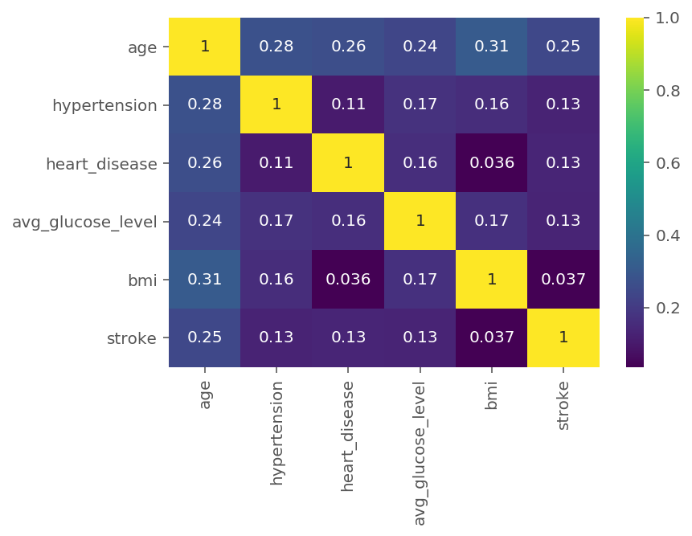

```python
#Heatmap
sns.heatmap(stroke_data.corr(), cmap='viridis', annot=True)
```

## Univariate Visualisation

Taking a look at the bar chart of 'work_type' attribute

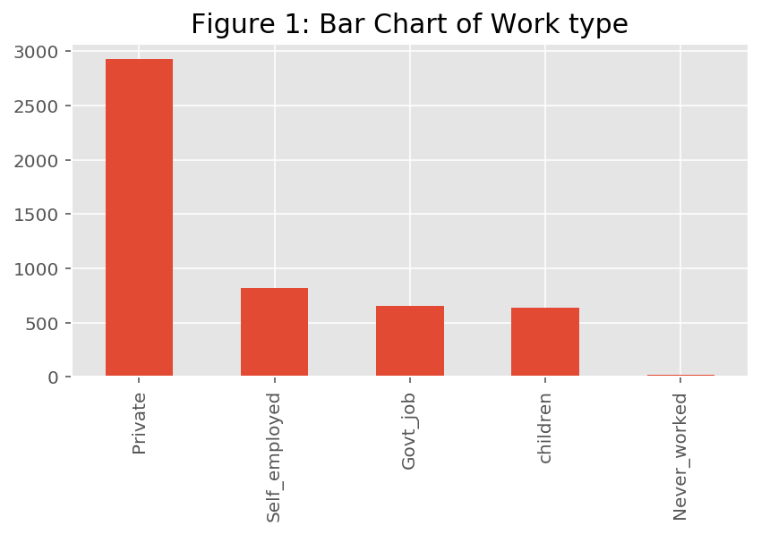

```python
#Bar Chart of work type
ax = stroke_data['work_type'].value_counts().plot(kind = 'bar')
ax.set_xticklabels(ax.get_xticklabels(), rotation = 90)
plt.tight_layout()
plt.title('Figure 1: Bar Chart of Work type', fontsize = 15)
plt.show();
```

There are 3 major sectors people work in which is 'Private', 'Self_employed', 'Govt_job'. Most of the people in this dataset are 'Private' sector employees which are around 3000 followed by 'Self_employed' around 800 and 'Govt_job' around 600. There are neglible people in this dataset who have never worked in any sector and the remaining are children.

### Pie chart of Marital status

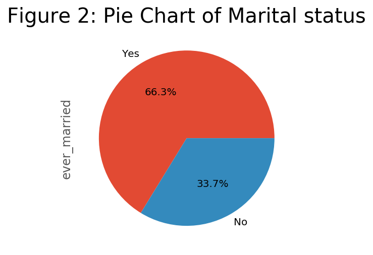

```python
#Pie chart of ever_married
ax = stroke_data['ever_married'].value_counts().plot(kind = 'pie', autopct="%.1f%%")
plt.title('Figure 2: Pie Chart of Marital status', fontsize = 20)
plt.show();
```

From the above pie chart, it can be said that this dataset contains 66.3% of people who are married and 33.7% are unmarried.

### Histogram of Age attribute

Histogram of age with kernal density

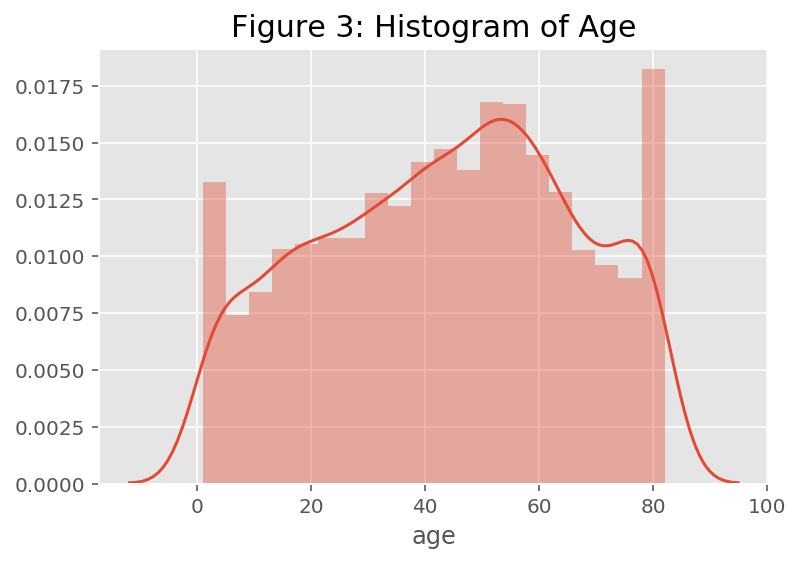

```python
sns.distplot(stroke_data['age'], kde=True).set_title('Figure 3: Histogram of Age', fontsize = 15)
plt.show();
```

Most people in this dataset are between 40 to 60. Maximum number of people are in their 80s.

### Count Plot of Smoking status

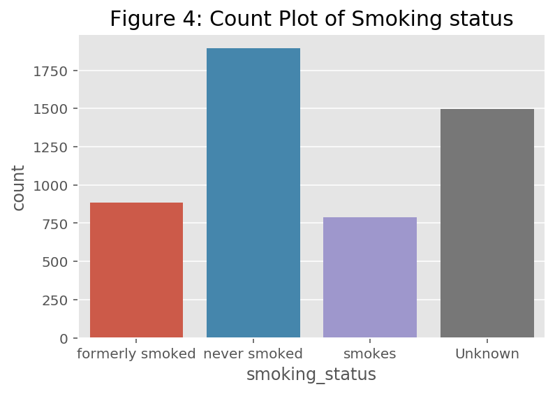

```python
#Count plot of Smoking status
sns.countplot(data=stroke_data, x="smoking_status").set_title('Figure 4: Count Plot of Smoking status', fontsize = 15)
plt.show()
```

It can be seen that most people in this dataset have never smoked. There are around 1500 people whose exact smoking status is not known. If a person is a smoker or formerly a smoker increases the risk of having a stroke.

## Bivariate Visualisations

Distribution plot of BMI by Gender

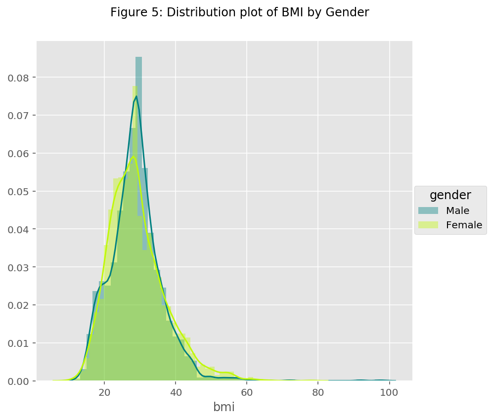

```python
#Gender vs bmi
s=sns.FacetGrid(stroke_data,
                height=6,
                hue="gender", palette={'Male': "#008080", 'Female': "#C1F80A"});

s=s.map(sns.distplot,
        'bmi');
s.add_legend(frameon=True)
s.fig.subplots_adjust(top=0.9)
s.fig.suptitle('Figure 5: Distribution plot of BMI by Gender')
plt.show()
```

### Distribution plot of age by stroke

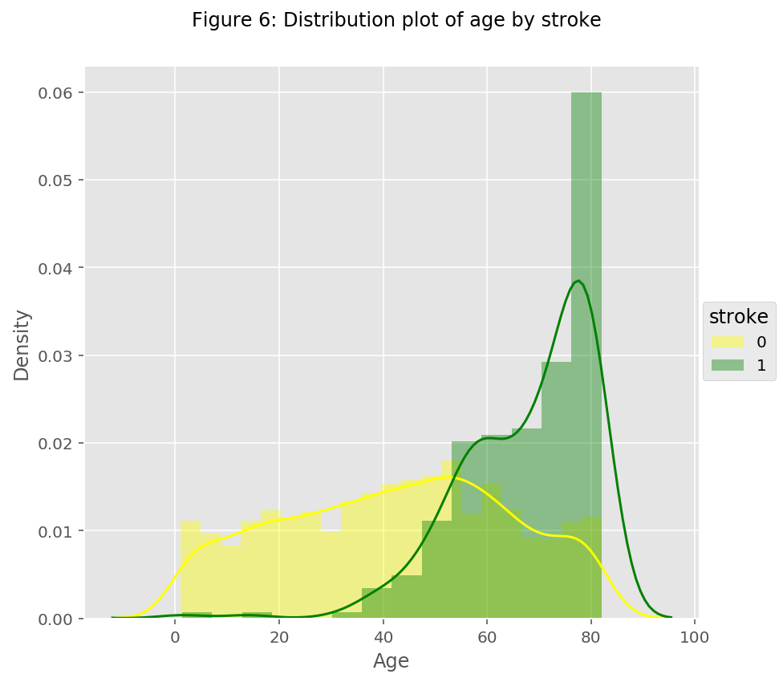

```python
s=sns.FacetGrid(stroke_data,
                height=6,
                hue="stroke", palette={0: "yellow", 1: "green"});

s=s.map(sns.distplot,
        'age');
s.set_axis_labels("Age", "Density")
s.add_legend(frameon=True)
s.fig.subplots_adjust(top=0.9)
s.fig.suptitle('Figure 6: Distribution plot of age by stroke')
plt.show()
```

Density of people aged 60 to 80 suffered more from a stroke. Therefore, older people are more likely to suffer from stroke than younger people.

### Bar chart for the relationship between Gender and Stroke

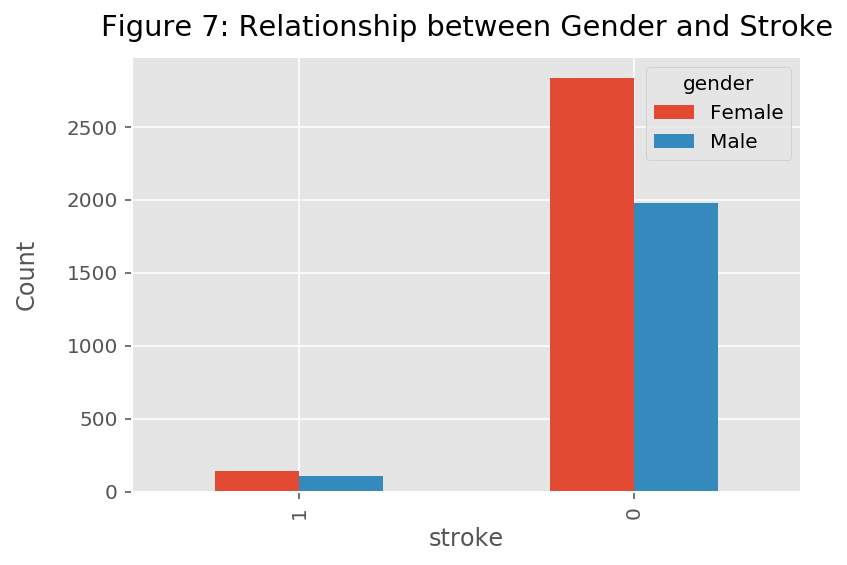

```python
gc=stroke_data[['gender','stroke']].groupby(['stroke','gender'])
oc=[1,0]
rc = gc.size().reindex(oc,level=0)
rc.unstack().plot.bar()
plt.ylabel("Count", labelpad=14)
plt.title("Figure 7: Relationship between Gender and Stroke", y=1.02)
plt.show()
```

More number of females can be seen to have suffered by stroke as compared to males.

### Distribution plot of Average glucose level by stroke

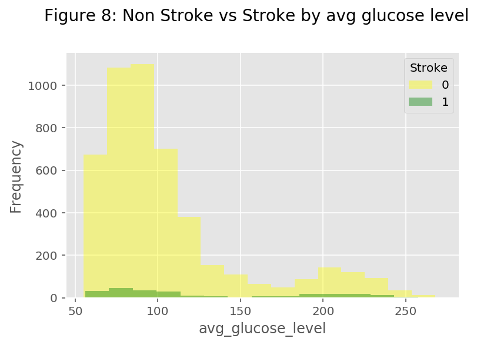

```python
fig = plt.figure(figsize = (6, 4))
title = fig.suptitle("Figure 8: Non Stroke vs Stroke by avg glucose level", fontsize=14)
fig.subplots_adjust(top=0.85, wspace=0.3)
ax = fig.add_subplot(1,1, 1)
ax.set_xlabel("Average glucose level")
ax.set_ylabel("Frequency")

g = sns.FacetGrid(stroke_data, hue='stroke', palette={0: "yellow", 1: "green"})
g.map(sns.distplot, 'avg_glucose_level', kde=False, bins=15, ax=ax)
ax.legend(title='Stroke')
plt.close(2)
```

### Distribution plot of BMI by Stroke

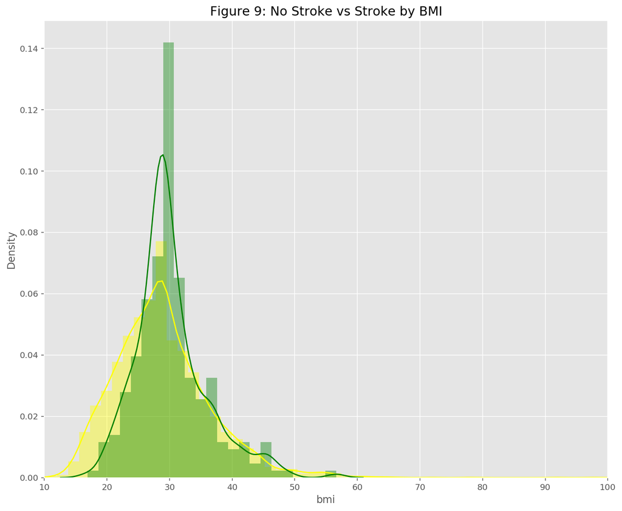

```python
plt.figure(figsize=(12,10))

sns.distplot(stroke_data[stroke_data['stroke'] == 0]["bmi"], color='yellow')
sns.distplot(stroke_data[stroke_data['stroke'] == 1]["bmi"], color='green')

plt.title('Figure 9: No Stroke vs Stroke by BMI', fontsize=15)
plt.xlim([10,100])
plt.ylabel("Density")
plt.show()
```

Density of people having BMI between 25 to 35 suffered stroke more as compared to others. Moreover, higher BMI will not increase the risk of stroke.